# caso_7.2_student

**Disclaimer**: Notebooks translated to Spanish are distributed as an optional aid to assist in your learning and comprehension. We make no guarantees that the translations are completely accurate nor that the translated code blocks will run properly.

## ¿Los tipos de delitos cometidos en Chicago dependen de la ubicación y la hora?

## Objetivos (3 min)

En el caso anterior, aprendimos cómo usar la prueba $ t $ y ANOVA para estudiar los cambios en la media de diferentes poblaciones. El objetivo principal de este caso es aprender a detectar posibles interacciones entre variables categóricas. Al final de este caso, debería haber aprendido cómo usar *tablas de contingencia* para explorar y diseñar hipótesis de posibles dependencias entre las características categóricas de sus datos. Además, debería haber aprendido cómo realizar una prueba $ \ chi ^ 2 $ (prueba de Chi-cuadrado) para examinar las dependencias en las categorías que hipotetizó anteriormente.

```python
import pandas as pd
import numpy as np
from scipy.stats import chi2_contingency
import matplotlib.pyplot as plt
from scipy.stats import chi2
```

## Introducción (5 min)

**Contexto de Negocio.** Anteriormente, hemos investigado los datos de delitos del departamento de policía de Chicago y descubrimos muchos factores potenciales que podrían estar asociados con eventos de delito. Ahora, el departamento de policía quiere que finalice su informe para que puedan comenzar a implementar algunas estrategias basadas en sus hallazgos. Sin embargo, debido a que la implementación de una nueva estrategia requiere muchos recursos, quieren que confirme que los patrones que observó no se deben simplemente a la aleatoriedad.

**Problema de Negocio.** El departamento quiere que usted responda: **"¿Los patrones delictivos que observó en su análisis anterior se deben simplemente al azar, o representan una señal procesable?"**

**Contexto Analítico.** En este caso, aprenderemos cómo realizar pruebas de hipótesis para descubrir si dos variables discretas son independientes entre sí o si hay patrones entre ellas que no se deben al azar. Esto establece si la interacción observada entre tales variables durante el análisis exploratorio de datos es **estadísticamente significativa**. El procedimiento de prueba generalmente se conoce como **prueba de Chi-cuadrado** y se realiza en tablas de contigencia.

El caso está estructurado de la siguiente manera: (1) usted configurará la tabla de contingencia para el tipo de delito frente a la ubicación; (2) aprenderá sobre la prueba de chi-cuadrado y la aplicará para determinar la significación estadística del patrón que observamos durante la EDA; y (3) aplique esta prueba a algunos otros patrones que observamos antes.

Tenga en cuenta que los nombres tanto del dataset como de los campos que lo componen están en idioma inglés, por lo tanto, algunas de las variables o dataframes se nombrarán en este idioma para que estos sean consecuentes.

```python
df = pd.read_csv('Chicago_crime_data.csv', dtype={'ID': object, 'beat_num': object})
pd.options.display.max_rows = 200
```

```python
df.columns
```

```
Index(['ID', 'Case Number', 'Date', 'Block', 'IUCR', 'Primary Type',
       'Description', 'Location Description', 'Arrest', 'Domestic', 'beat_num',
       'District', 'Ward', 'Community Area', 'FBI Code', 'X Coordinate',
       'Y Coordinate', 'Year', 'Updated On', 'Latitude', 'Longitude',
       'Location'],
      dtype='object')
```

```python
cross=pd.crosstab(df['Domestic'], df['Arrest'])
cross
```

| Arrest Domestic | False | True |
| --- | --- | --- |
| False | 179478 | 45016 |
| True | 35276 | 7408 |

```python
chi2_contingency(cross)
```

```
(165.20895928326414,
 8.234997211784021e-38,
 1,
 array([[ 180445.18813675,   44048.81186325],
        [  34308.81186325,    8375.18813675]]))
```

## Tablas de contingencia (20 min)

Recuerde que nuestro dataset de crímenes de Chicago original consistía en registros de incidentes individuales. Para cualquier variable dada (por ejemplo, tipo de delito primario), cada evento tiene un valor particular. Por ejemplo, el primer incidente en el dataset es un caso de robo y ocurrió en un departamento:

```python
df.head()
```

|  | ID | Case Number | Date | Block | IUCR | Primary Type | Description | Location Description | Arrest | Domestic | ... | Ward | Community Area | FBI Code | X Coordinate | Y Coordinate | Year | Updated On | Latitude | Longitude | Location |
| --- | --- | --- | --- | --- | --- | --- | --- | --- | --- | --- | --- | --- | --- | --- | --- | --- | --- | --- | --- | --- | --- |
| 0 | 11192233 | JB100016 | 12/31/17 23:58 | 046XX N ST LOUIS AVE | 630 | BURGLARY | ATTEMPT FORCIBLE ENTRY | APARTMENT | False | False | ... | 33.0 | 14 | 5 | 1152214.0 | 1930694.0 | 2017 | 5/4/18 15:51 | 41.965694 | -87.715726 | (41.965693651, -87.715726125) |
| 1 | 11196379 | JB105867 | 12/31/17 23:50 | 024XX N LAKE SHORE DR NB | 460 | BATTERY | SIMPLE | MOVIE HOUSE/THEATER | False | False | ... | 43.0 | 7 | 08B | 1175293.0 | 1916610.0 | 2017 | 5/4/18 15:51 | 41.926559 | -87.631294 | (41.926558908, -87.631294073) |
| 2 | 11192540 | JB100551 | 12/31/17 23:48 | 001XX E SUPERIOR ST | 890 | THEFT | FROM BUILDING | HOTEL/MOTEL | False | False | ... | 42.0 | 8 | 6 | 1177508.0 | 1905401.0 | 2017 | 5/4/18 15:51 | 41.895751 | -87.623496 | (41.895750913, -87.623495923) |
| 3 | 11192239 | JB100032 | 12/31/17 23:45 | 019XX S CANAL ST | 1320 | CRIMINAL DAMAGE | TO VEHICLE | STREET | False | True | ... | 25.0 | 31 | 14 | 1173432.0 | 1891037.0 | 2017 | 5/4/18 15:51 | 41.856427 | -87.638893 | (41.856426716, -87.638892854) |
| 4 | 11192254 | JB100003 | 12/31/17 23:45 | 115XX S STATE ST | 041A | BATTERY | AGGRAVATED: HANDGUN | RESIDENCE | False | True | ... | 34.0 | 53 | 04B | 1178329.0 | 1828012.0 | 2017 | 5/4/18 15:51 | 41.683369 | -87.622830 | (41.683369303, -87.622829524) |

5 rows × 22 columns

Recuerde también que usamos tablas de contingencia para investigar posibles correlaciones y relaciones entre las diferentes variables. La siguiente tabla muestra la tabla de contingencia completa para `Primary Type` vs. `Location` (tipo primario del incidente y su ubicación):

```python
type_loc_cross = pd.crosstab(df["Primary Type"], df["Location Description"])
type_loc_cross
```

| Location Description Primary Type | ABANDONED BUILDING | AIRCRAFT | AIRPORT BUILDING NON-TERMINAL - NON-SECURE AREA | AIRPORT BUILDING NON-TERMINAL - SECURE AREA | AIRPORT EXTERIOR - NON-SECURE AREA | AIRPORT EXTERIOR - SECURE AREA | AIRPORT PARKING LOT | AIRPORT TERMINAL LOWER LEVEL - NON-SECURE AREA | AIRPORT TERMINAL LOWER LEVEL - SECURE AREA | AIRPORT TERMINAL MEZZANINE - NON-SECURE AREA | ... | VACANT LOT | VACANT LOT/LAND | VEHICLE - DELIVERY TRUCK | VEHICLE - OTHER RIDE SERVICE | VEHICLE - OTHER RIDE SHARE SERVICE (E.G., UBER, LYFT) | VEHICLE NON-COMMERCIAL | VEHICLE-COMMERCIAL | VESTIBULE | WAREHOUSE | YARD |
| --- | --- | --- | --- | --- | --- | --- | --- | --- | --- | --- | --- | --- | --- | --- | --- | --- | --- | --- | --- | --- | --- |
| ARSON | 10 | 0 | 0 | 0 | 0 | 0 | 0 | 0 | 0 | 0 | ... | 0 | 7 | 0 | 0 | 0 | 100 | 2 | 0 | 1 | 0 |
| ASSAULT | 5 | 0 | 6 | 1 | 9 | 2 | 8 | 8 | 1 | 0 | ... | 0 | 15 | 1 | 11 | 0 | 98 | 3 | 0 | 20 | 0 |
| BATTERY | 12 | 19 | 5 | 6 | 13 | 2 | 4 | 25 | 5 | 1 | ... | 0 | 37 | 0 | 42 | 4 | 646 | 21 | 0 | 28 | 0 |
| BURGLARY | 54 | 0 | 0 | 0 | 0 | 0 | 0 | 1 | 0 | 0 | ... | 0 | 247 | 0 | 0 | 0 | 13 | 3 | 0 | 74 | 0 |
| CONCEALED CARRY LICENSE VIOLATION | 0 | 0 | 1 | 2 | 1 | 0 | 0 | 0 | 1 | 0 | ... | 0 | 0 | 0 | 0 | 0 | 3 | 0 | 0 | 0 | 0 |
| CRIM SEXUAL ASSAULT | 19 | 0 | 0 | 1 | 0 | 0 | 0 | 0 | 0 | 0 | ... | 0 | 4 | 0 | 2 | 2 | 42 | 3 | 0 | 2 | 0 |
| CRIMINAL DAMAGE | 30 | 0 | 5 | 0 | 2 | 2 | 14 | 3 | 1 | 1 | ... | 0 | 132 | 0 | 6 | 0 | 543 | 26 | 0 | 27 | 0 |
| CRIMINAL TRESPASS | 29 | 0 | 5 | 0 | 2 | 1 | 1 | 87 | 2 | 0 | ... | 0 | 21 | 0 | 0 | 0 | 89 | 4 | 0 | 14 | 0 |
| DECEPTIVE PRACTICE | 2 | 2 | 19 | 11 | 27 | 3 | 11 | 8 | 4 | 3 | ... | 0 | 1 | 2 | 23 | 3 | 41 | 32 | 0 | 21 | 0 |
| GAMBLING | 1 | 0 | 0 | 0 | 0 | 0 | 0 | 0 | 0 | 0 | ... | 0 | 1 | 0 | 0 | 0 | 0 | 0 | 0 | 0 | 0 |
| HOMICIDE | 0 | 0 | 0 | 0 | 0 | 0 | 0 | 0 | 0 | 0 | ... | 3 | 0 | 0 | 0 | 0 | 0 | 0 | 1 | 0 | 22 |
| HUMAN TRAFFICKING | 0 | 0 | 0 | 0 | 0 | 0 | 0 | 0 | 0 | 0 | ... | 0 | 0 | 0 | 0 | 0 | 0 | 0 | 0 | 0 | 0 |
| INTERFERENCE WITH PUBLIC OFFICER | 6 | 0 | 0 | 0 | 1 | 0 | 0 | 0 | 0 | 0 | ... | 0 | 4 | 0 | 1 | 0 | 29 | 2 | 0 | 0 | 0 |
| INTIMIDATION | 0 | 0 | 0 | 0 | 0 | 0 | 0 | 0 | 0 | 0 | ... | 0 | 0 | 0 | 0 | 0 | 0 | 0 | 0 | 0 | 0 |
| KIDNAPPING | 0 | 0 | 0 | 0 | 0 | 0 | 0 | 0 | 1 | 0 | ... | 0 | 0 | 0 | 0 | 0 | 6 | 1 | 0 | 0 | 0 |
| LIQUOR LAW VIOLATION | 0 | 0 | 0 | 0 | 0 | 0 | 0 | 0 | 0 | 0 | ... | 0 | 0 | 0 | 0 | 0 | 1 | 0 | 0 | 0 | 0 |
| MOTOR VEHICLE THEFT | 0 | 0 | 5 | 0 | 9 | 1 | 12 | 0 | 0 | 0 | ... | 0 | 35 | 1 | 0 | 0 | 174 | 7 | 0 | 5 | 0 |
| NARCOTICS | 88 | 1 | 0 | 2 | 0 | 0 | 1 | 0 | 3 | 0 | ... | 0 | 171 | 0 | 0 | 0 | 621 | 6 | 0 | 4 | 0 |
| NON-CRIMINAL | 0 | 0 | 0 | 1 | 0 | 0 | 0 | 0 | 1 | 0 | ... | 0 | 0 | 0 | 1 | 0 | 0 | 0 | 0 | 0 | 0 |
| NON-CRIMINAL (SUBJECT SPECIFIED) | 0 | 0 | 0 | 0 | 0 | 0 | 0 | 0 | 0 | 0 | ... | 0 | 0 | 0 | 0 | 0 | 0 | 0 | 0 | 0 | 0 |
| OBSCENITY | 0 | 0 | 0 | 0 | 0 | 0 | 0 | 0 | 0 | 0 | ... | 0 | 0 | 0 | 0 | 0 | 0 | 0 | 0 | 0 | 0 |
| OFFENSE INVOLVING CHILDREN | 0 | 0 | 0 | 0 | 0 | 0 | 0 | 1 | 1 | 0 | ... | 0 | 0 | 0 | 0 | 0 | 18 | 0 | 0 | 0 | 0 |
| OTHER NARCOTIC VIOLATION | 0 | 0 | 0 | 0 | 0 | 0 | 0 | 0 | 0 | 0 | ... | 0 | 0 | 0 | 0 | 0 | 0 | 0 | 0 | 0 | 0 |
| OTHER OFFENSE | 18 | 1 | 5 | 4 | 6 | 2 | 4 | 2 | 0 | 0 | ... | 0 | 13 | 0 | 1 | 0 | 243 | 11 | 0 | 8 | 0 |
| PROSTITUTION | 0 | 0 | 0 | 0 | 0 | 0 | 0 | 0 | 0 | 0 | ... | 0 | 0 | 0 | 0 | 0 | 14 | 0 | 0 | 0 | 0 |
| PUBLIC INDECENCY | 0 | 0 | 0 | 0 | 0 | 0 | 0 | 0 | 0 | 0 | ... | 0 | 0 | 0 | 0 | 0 | 0 | 0 | 0 | 0 | 0 |
| PUBLIC PEACE VIOLATION | 5 | 15 | 1 | 2 | 1 | 0 | 0 | 0 | 0 | 0 | ... | 0 | 7 | 0 | 0 | 0 | 6 | 0 | 0 | 0 | 0 |
| ROBBERY | 9 | 0 | 0 | 0 | 0 | 0 | 0 | 0 | 0 | 0 | ... | 0 | 19 | 0 | 9 | 3 | 139 | 6 | 0 | 3 | 0 |
| SEX OFFENSE | 1 | 2 | 0 | 1 | 0 | 1 | 0 | 0 | 0 | 0 | ... | 0 | 0 | 0 | 4 | 2 | 21 | 3 | 0 | 1 | 0 |
| STALKING | 0 | 0 | 0 | 0 | 0 | 0 | 0 | 0 | 0 | 0 | ... | 0 | 0 | 0 | 0 | 0 | 1 | 0 | 0 | 0 | 0 |
| THEFT | 29 | 34 | 47 | 49 | 19 | 11 | 31 | 77 | 37 | 6 | ... | 0 | 116 | 16 | 47 | 1 | 1675 | 149 | 0 | 107 | 0 |
| WEAPONS VIOLATION | 12 | 0 | 0 | 0 | 1 | 0 | 0 | 0 | 0 | 0 | ... | 0 | 41 | 0 | 2 | 0 | 200 | 3 | 0 | 0 | 0 |

32 rows × 128 columns

La tabla resultante es bastante grande. Una forma de lidiar con esto es seleccionar algunas categorías que puedan ser de interés para nuestro cliente y comenzar nuestro análisis con ellas. Sin embargo, antes de hacer esto, a menudo es una buena práctica agrupar todas nuestras características en categorías más grandes (significativas). Dos razones para esto son:

1. Evitamos perder datos que pueden contener patrones valiosos para nuestro cliente (lo que puede suceder si preseleccionamos categorías desde el principio).
2. Si encontramos una posible dependencia entre dos categorías más grandes, nos dirá que analicemos sus subcategorías y las estudiemos con más detalle.

Afortunadamente para nosotros, hemos contratado a un pasante que creó los diccionarios `Locations_dict` y `Offenses_dict` que contienen un posible conjunto de agrupaciones para nuestras categorías:

```python
Locations_dict                     ={
    'Airport & Related' :{
        'AIRCRAFT',
        'AIRPORT BUILDING NON-TERMINAL - NON-SECURE AREA',
        'AIRPORT BUILDING NON-TERMINAL - SECURE AREA',
        'AIRPORT EXTERIOR - NON-SECURE AREA',
        'AIRPORT EXTERIOR - SECURE AREA', 'AIRPORT PARKING LOT',
        'AIRPORT TERMINAL LOWER LEVEL - NON-SECURE AREA',
        'AIRPORT TERMINAL LOWER LEVEL - SECURE AREA',
        'AIRPORT TERMINAL MEZZANINE - NON-SECURE AREA',
        'AIRPORT TERMINAL UPPER LEVEL - NON-SECURE AREA',
        'AIRPORT TERMINAL UPPER LEVEL - SECURE AREA',
        'AIRPORT TRANSPORTATION SYSTEM (ATS)',
        'AIRPORT VENDING ESTABLISHMENT', 'AIRPORT/AIRCRAFT'
    } ,

    'Hospitals & Related':{
        'ANIMAL HOSPITAL',
        'HOSPITAL BUILDING/GROUNDS',
        'MEDICAL/DENTAL OFFICE',
        'NURSING HOME',
        'NURSING HOME/RETIREMENT HOME',
    },

    'Residential & Related':{
        'APARTMENT',
        'BASEMENT',
        'STAIRWELL',
        'CHA APARTMENT', #Chicago Housing Autority
        'CHA HALLWAY',
        'CHA HALLWAY/STAIRWELL/ELEVATOR',
        'CHA PARKING LOT',
        'CHA PARKING LOT/GROUNDS',
        'DRIVEWAY - RESIDENTIAL',
        'PORCH',
        'RESIDENCE',
        'RESIDENCE PORCH/HALLWAY',
        'RESIDENCE-GARAGE',
        'RESIDENTIAL YARD (FRONT/BACK)',
        'ROOMING HOUSE',
        'GARAGE',
        'HOTEL/MOTEL',
        'HOUSE',
    },

    'Colleges & Related': {
        'SCHOOL, PRIVATE, BUILDING',
        'SCHOOL, PRIVATE, GROUNDS',
        'SCHOOL, PUBLIC, BUILDING',
        'SCHOOL, PUBLIC, GROUNDS',
        'COLLEGE/UNIVERSITY GROUNDS',
        'COLLEGE/UNIVERSITY RESIDENCE HALL',
        'DAY CARE CENTER',
        'SCHOOL YARD',
                         },

    'Goverment Buildings & Related':{
        'FEDERAL BUILDING',
        'FIRE STATION',
        'FOREST PRESERVE',
        'POLICE FACILITY/VEH PARKING LOT',
        'GOVERNMENT BUILDING/PROPERTY',
        'JAIL / LOCK-UP FACILITY',
        'LIBRARY',
        'PARK PROPERTY',},

    'Liquor Stores & Related':{
        'TAVERN',
        'TAVERN/LIQUOR STORE',
        'BAR OR TAVERN',
        'CLUB',
        'POOL ROOM',
         },

    'Stores & Related':{
        'SMALL RETAIL STORE',
        'APPLIANCE STORE',
        'BARBERSHOP',
        'ATHLETIC CLUB',
        'BOWLING ALLEY',
        'CAR WASH',
        'CLEANING STORE',
        'COIN OPERATED MACHINE',
        'COMMERCIAL / BUSINESS OFFICE',
        'CONVENIENCE STORE',
        'DEPARTMENT STORE',
        'DRUG STORE',
        'VESTIBULE',
        'GAS STATION',
        'GAS STATION DRIVE/PROP.',
        'RESTAURANT',
        'GROCERY FOOD STORE',
        'RETAIL STORE',
        'MOVIE HOUSE/THEATER',
        'FACTORY/MANUFACTURING BUILDING',
        'NEWSSTAND',
        'PARKING LOT',},

    'Vehicles & Related':{
        'VEHICLE - DELIVERY TRUCK',
        'VEHICLE - OTHER RIDE SERVICE',
        'VEHICLE - OTHER RIDE SHARE SERVICE (E.G., UBER, LYFT)',
        'VEHICLE NON-COMMERCIAL',
        'VEHICLE-COMMERCIAL','TAXICAB', 'AUTO',
        'AUTO / BOAT / RV DEALERSHIP','BOAT/WATERCRAFT', 'GANGWAY', 'OTHER COMMERCIAL TRANSPORTATION',


    },

    'Public Transport & Related':{
        'CTA "L" PLATFORM',
        'CTA BUS',
        'CTA BUS STOP',
        'CTA GARAGE / OTHER PROPERTY',
        'CTA PLATFORM',
        'CTA PROPERTY',
        'CTA STATION',
        'CTA TRACKS - RIGHT OF WAY',
        'CTA TRAIN', 'OTHER RAILROAD PROP / TRAIN DEPOT',

                    },

    'Street & Related': {
        'ALLEY',
        'BRIDGE',
        'CEMETARY',
        'CHURCH',
        'CHURCH/SYNAGOGUE/PLACE OF WORSHIP',
        'CONSTRUCTION SITE',
        'DRIVEWAY',
        'YARD',
        'VACANT LOT',
        'VACANT LOT/LAND',
        'SIDEWALK',
        'PARKING LOT/GARAGE(NON.RESID.)',
        'ABANDONED BUILDING',
        'STREET',
        'HIGHWAY/EXPRESSWAY',
        'HALLWAY',
        'LAKEFRONT/WATERFRONT/RIVERBANK',
        'SPORTS ARENA/STADIUM'

    },

    'Bank & Related':{
        'BANK',
        'ATM (AUTOMATIC TELLER MACHINE)',
        'CREDIT UNION',
        'CURRENCY EXCHANGE',
        'RIVER BANK',
        'SAVINGS AND LOAN',
        'PAWN SHOP',
        'WAREHOUSE'},

    'Other Locations':{'OTHER', }

}


Offenses_dict={
    'Theft Related': {
        'BURGLARY',
        'THEFT',
        'CRIMINAL TRESPASS',
        'MOTOR VEHICLE THEFT',
        'ROBBERY',
        },

    'Property Damage': {
        'CRIMINAL DAMAGE',
        'ARSON',
        },

    'Violence & Related' :{
        'BATTERY',
        'ASSAULT',
        'KIDNAPPING',
        'HOMICIDE',
        },

    'Sexual Offenses & Related':{
        'CRIM SEXUAL ASSAULT',
        'SEX OFFENSE',
        'OBSCENITY',
        'HUMAN TRAFFICKING',
        'PROSTITUTION',
        'PUBLIC INDECENCY',
        'STALKING',
        'OFFENSE INVOLVING CHILDREN'},

    'Dangerous practices':{
        'DECEPTIVE PRACTICE',
        'WEAPONS VIOLATION',
        'INTIMIDATION',
        'CONCEALED CARRY LICENSE VIOLATION',
        'INTERFERENCE WITH PUBLIC OFFICER'},

    'Substances & Related':{
        'NARCOTICS',
        'OTHER NARCOTIC VIOLATION',
        'GAMBLING',
        'LIQUOR LAW VIOLATION'},

    'Other Offenses':{
        'PUBLIC PEACE VIOLATION'
        'NON-CRIMINAL',
        'OTHER OFFENSE',
        'NON-CRIMINAL (SUBJECT SPECIFIED)' }}
```

### Ejercicio 1: (10 min)

Use los diccionarios provistos para crear una tabla de contingencia de las categorías agrupadas. ¿Qué conclusiones puedes sacar?

**Respuesta.**

Para visualizar los datos un poco mejor, calculemos y grafiquemos las proporciones de delitos que ocurrieron en cada categoría de ubicación. Esto puede hacerse de la siguiente manera:

```python
Offense_Location_prop= round(Offense_Location_cross.div(Offense_Location_cross.sum(axis=1), axis=0)*100,2)
Offense_Location_prop
```

| Location_cat Offenses_cat | Airport & Related | Bank & Related | Colleges & Related | Goverment Buildings & Related | Hospitals & Related | Liquor Stores & Related | Other Locations | Public Transport & Related | Residential & Related | Stores & Related | Street & Related | Vehicles & Related |
| --- | --- | --- | --- | --- | --- | --- | --- | --- | --- | --- | --- | --- |
| Dangerous practices | 1.05 | 6.38 | 0.74 | 0.86 | 0.59 | 0.94 | 9.68 | 1.82 | 39.30 | 13.76 | 22.47 | 2.42 |
| Other Offenses | 0.35 | 0.15 | 1.46 | 1.33 | 0.87 | 0.28 | 7.86 | 0.21 | 55.43 | 4.82 | 25.71 | 1.53 |
| Property Damage | 0.12 | 0.40 | 1.13 | 0.93 | 0.38 | 0.34 | 2.77 | 1.84 | 41.19 | 5.65 | 42.88 | 2.38 |
| Sexual Offenses & Related | 0.15 | 0.10 | 4.69 | 2.19 | 2.49 | 0.55 | 4.03 | 1.69 | 57.41 | 1.88 | 22.82 | 1.99 |
| Substances & Related | 0.50 | 0.06 | 1.58 | 5.74 | 0.80 | 0.89 | 1.24 | 1.35 | 15.67 | 2.99 | 63.95 | 5.24 |
| Theft Related | 0.58 | 0.48 | 1.14 | 1.28 | 0.68 | 1.18 | 4.29 | 2.53 | 26.84 | 19.73 | 38.89 | 2.39 |
| Violence & Related | 0.26 | 0.18 | 4.30 | 1.47 | 1.32 | 1.10 | 2.57 | 1.87 | 46.27 | 6.12 | 33.10 | 1.45 |

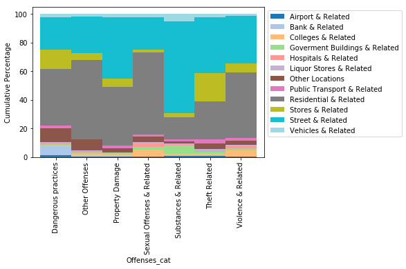

```python
plt_prop = Offense_Location_prop.plot(kind='bar', stacked = True, width = 1,colormap='tab20')
plt_prop.legend(bbox_to_anchor=(1,1), loc='upper left', ncol = 1)
_ = plt.ylabel("Cumulative Percentage")
```

### Ejercicio 2: (5 min)

¿Qué conclusiones puede sacar de los resultados obtenidos en el punto anterior?

**Respuesta.**

También podemos dar un giro y construir la tabla con las proporciones de los tipos de delitos para cada categoría de ubicación. Observar ambos conjuntos de proporciones puede darnos información que no era tan evidente en la tabla de contingencia misma:

```python
Location_Offense_prop= round(Offense_Location_cross.div(Offense_Location_cross.sum(axis=0), axis=1)*100,2)
Location_Offense_prop
```

| Location_cat Offenses_cat | Airport & Related | Bank & Related | Colleges & Related | Goverment Buildings & Related | Hospitals & Related | Liquor Stores & Related | Other Locations | Public Transport & Related | Residential & Related | Stores & Related | Street & Related | Vehicles & Related |
| --- | --- | --- | --- | --- | --- | --- | --- | --- | --- | --- | --- | --- |
| Dangerous practices | 20.74 | 65.81 | 3.29 | 5.24 | 6.18 | 8.86 | 20.67 | 8.29 | 9.71 | 10.44 | 5.62 | 9.92 |
| Other Offenses | 4.94 | 1.07 | 4.63 | 5.85 | 6.53 | 1.88 | 12.02 | 0.68 | 9.81 | 2.62 | 4.60 | 4.50 |
| Property Damage | 2.80 | 5.01 | 6.14 | 6.97 | 4.83 | 3.88 | 7.24 | 10.26 | 12.47 | 5.25 | 13.13 | 11.98 |
| Sexual Offenses & Related | 0.74 | 0.26 | 5.15 | 3.33 | 6.49 | 1.29 | 2.14 | 1.91 | 3.52 | 0.35 | 1.42 | 2.03 |
| Substances & Related | 4.94 | 0.30 | 3.49 | 17.60 | 4.22 | 4.19 | 1.32 | 3.08 | 1.94 | 1.13 | 8.00 | 10.75 |
| Theft Related | 51.03 | 22.32 | 22.44 | 35.02 | 31.82 | 49.86 | 40.84 | 51.28 | 29.60 | 66.82 | 43.39 | 43.69 |
| Violence & Related | 14.81 | 5.23 | 54.85 | 25.99 | 39.92 | 30.03 | 15.78 | 24.50 | 32.95 | 13.39 | 23.85 | 17.14 |

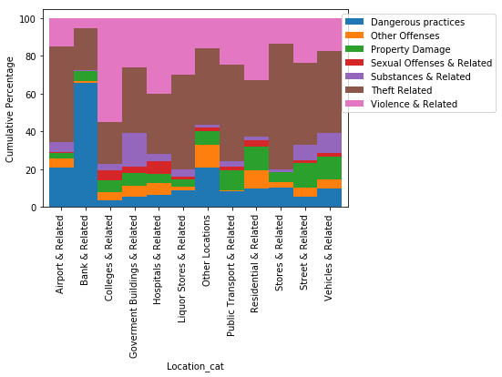

```python
plt_prop_new = Location_Offense_prop.transpose().plot(kind='bar', stacked = True, width = 1)
plt_prop_new.legend(bbox_to_anchor=(1.5,1), loc='upper right', ncol = 1)
_ = plt.ylabel("Cumulative Percentage")
```

### Ejercicio 3: (5 min)

¿Qué conclusiones puede sacar de la tabla y el gráfico de barras apiladas de arriba? ¿Estos resultados todavía respaldan una interacción entre el tipo y ubicación del delito?

**Respuesta.**

## Prueba de chi-cuadrado basada en tablas de contingencia (10 min)

Hemos generado la tabla de contingencia de `Primary Type` versus`Location Description` y observamos que los desgloses específicos de ubicaciones del tipo de delito no son uniformes. Concluimos que puede haber una interacción entre estas dos variables. Podemos probar formalmente si las variaciones que observamos reflejan las diferencias reales o si son solo un subproducto de la aleatoriedad. Hay muchas formas diferentes de realizar la prueba, pero nos centraremos en la prueba más utilizada: la **prueba Chi-cuadrado** ($\chi^2$-test). La hipótesis nula para la prueba de Chi-cuadrado es:

$$ H_0:\text{El tipo primario es independiente de la descripción de la ubicación} $$

No necesitamos una definición formal de "independiente". Intuitivamente, "independencia entre dos variables" significa que la distribución de valores de una variable permanece igual incluso cuando cambia el valor de la segunda variable (y viceversa). En nuestro caso, esto significa que las proporciones de los diferentes tipos de delitos siguen siendo las mismas, incluso cuando miramos diferentes lugares de delitos. Los datos parecen indicar lo contrario, así que analicemos cómo resumir numéricamente los datos para examinar formalmente la hipótesis nula:

```python
type_prop = (df["Primary Type"].value_counts()/df["Primary Type"].count()).sort_index()
type_prop
```

```
ARSON                                0.001662
ASSAULT                              0.072251
BATTERY                              0.184214
BURGLARY                             0.048657
CONCEALED CARRY LICENSE VIOLATION    0.000258
CRIM SEXUAL ASSAULT                  0.006105
CRIMINAL DAMAGE                      0.108703
CRIMINAL TRESPASS                    0.025507
DECEPTIVE PRACTICE                   0.067674
GAMBLING                             0.000715
HOMICIDE                             0.002526
HUMAN TRAFFICKING                    0.000030
INTERFERENCE WITH PUBLIC OFFICER     0.004068
INTIMIDATION                         0.000565
KIDNAPPING                           0.000711
LIQUOR LAW VIOLATION                 0.000715
MOTOR VEHICLE THEFT                  0.042612
NARCOTICS                            0.043638
NON-CRIMINAL                         0.000138
NON-CRIMINAL (SUBJECT SPECIFIED)     0.000007
OBSCENITY                            0.000322
OFFENSE INVOLVING CHILDREN           0.008541
OTHER NARCOTIC VIOLATION             0.000041
OTHER OFFENSE                        0.064508
PROSTITUTION                         0.002751
PUBLIC INDECENCY                     0.000037
PUBLIC PEACE VIOLATION               0.005607
ROBBERY                              0.044461
SEX OFFENSE                          0.003859
STALKING                             0.000711
THEFT                                0.240866
WEAPONS VIOLATION                    0.017539
Name: Primary Type, dtype: float64
```

Del mismo modo, las proporciones de todos los valores distintos de `Location Description` son:

```python
location_prop = (df["Location Description"].value_counts()/df["Location Description"].count()).sort_index()
location_prop
```

```
ABANDONED BUILDING                                       0.001235
AIRCRAFT                                                 0.000277
AIRPORT BUILDING NON-TERMINAL - NON-SECURE AREA          0.000371
AIRPORT BUILDING NON-TERMINAL - SECURE AREA              0.000299
AIRPORT EXTERIOR - NON-SECURE AREA                       0.000341
AIRPORT EXTERIOR - SECURE AREA                           0.000094
AIRPORT PARKING LOT                                      0.000322
AIRPORT TERMINAL LOWER LEVEL - NON-SECURE AREA           0.000793
AIRPORT TERMINAL LOWER LEVEL - SECURE AREA               0.000213
AIRPORT TERMINAL MEZZANINE - NON-SECURE AREA             0.000041
AIRPORT TERMINAL UPPER LEVEL - NON-SECURE AREA           0.000296
AIRPORT TERMINAL UPPER LEVEL - SECURE AREA               0.000861
AIRPORT TRANSPORTATION SYSTEM (ATS)                      0.000034
AIRPORT VENDING ESTABLISHMENT                            0.000442
AIRPORT/AIRCRAFT                                         0.000277
ALLEY                                                    0.019773
ANIMAL HOSPITAL                                          0.000180
APARTMENT                                                0.125190
APPLIANCE STORE                                          0.000344
ATHLETIC CLUB                                            0.001991
ATM (AUTOMATIC TELLER MACHINE)                           0.001995
AUTO                                                     0.000307
AUTO / BOAT / RV DEALERSHIP                              0.000052
BANK                                                     0.003859
BAR OR TAVERN                                            0.007362
BARBERSHOP                                               0.000868
BASEMENT                                                 0.000004
BOAT/WATERCRAFT                                          0.000094
BOWLING ALLEY                                            0.000138
BRIDGE                                                   0.000094
CAR WASH                                                 0.000513
CEMETARY                                                 0.000075
CHA APARTMENT                                            0.002796
CHA HALLWAY                                              0.000004
CHA HALLWAY/STAIRWELL/ELEVATOR                           0.000782
CHA PARKING LOT                                          0.000015
CHA PARKING LOT/GROUNDS                                  0.002246
CHURCH                                                   0.000007
CHURCH/SYNAGOGUE/PLACE OF WORSHIP                        0.002193
CLEANING STORE                                           0.000337
```

[output cut: 74 more lines]

```
STREET                                                   0.224476
TAVERN                                                   0.000007
TAVERN/LIQUOR STORE                                      0.002006
TAXICAB                                                  0.001576
VACANT LOT                                               0.000011
VACANT LOT/LAND                                          0.003260
VEHICLE - DELIVERY TRUCK                                 0.000075
VEHICLE - OTHER RIDE SERVICE                             0.000558
VEHICLE - OTHER RIDE SHARE SERVICE (E.G., UBER, LYFT)    0.000056
VEHICLE NON-COMMERCIAL                                   0.017677
VEHICLE-COMMERCIAL                                       0.001055
VESTIBULE                                                0.000004
WAREHOUSE                                                0.001179
YARD                                                     0.000082
Name: Location Description, dtype: float64
```

Según la hipótesis nula, el número esperado de ocurrencias para todas las combinaciones de valores de `Primary Type` y `Location Description`por pares debe ser el producto de los valores correspondientes en las dos tablas anteriores, multiplicado por el número total de registros en el conjunto de datos. Por ejemplo, el número total de casos de delitos de agresión (battery) en los apartamentos debe ser aproximadamente 0.184214 veces 0.125190 veces el número total de casos de delitos en todo nuestro dataset.

```python
primary_location_cross = pd.crosstab(df['Primary Type'], df['Location'])
g, p, dof, expctd = chi2_contingency(primary_location_cross)
print("p-value of Chi-square test for Primary Type vs. Location =", p)
```

```
p-value of Chi-square test for Primary Type vs. Location = 0.0
```

### Ejercicio 4: (10 min)

Nuestro cliente está interesado en crímenes violentos en áreas residenciales. Para reunir información, habló con un oficial de policía quien le dijo lo siguiente:

"Desde mi experiencia, los delitos violentos no discriminan por ubicación en las áreas residenciales. He visto que todo sucede en todas partes".

¿Qué opinas de esta afirmación? Use una prueba de Chi-cuadrado para verificar sus hallazgos.

**Respuesta.**

## Prueba de chi-cuadrado para tipo primario vs. día de la semana (25 min)

A veces, cuando realizamos la prueba de Chi-cuadrado, una de las variables (o incluso ambas) no es naturalmente discreta (por ejemplo, el tiempo del delito). Sin embargo, podemos discretizar la variable y realizar la prueba de Chi-cuadrado en las versiones discretizadas. Ahora discretizaremos la variable de tiempo en segmentos del día de la semana y probaremos si el día de la semana es independiente de los tipos de delitos. Esta prueba nos informará si debemos variar el despliegue de la fuerza policial según el día de la semana. Empecemos:

```python
# discreticemos el tiempo
df["date_py"] = pd.to_datetime(df.Date)
df["day_of_week"] = df.date_py.dt.dayofweek
type_dow_cross = pd.crosstab(df['Primary Type'], df['day_of_week'])
type_dow_cross
```

| day_of_week Primary Type | 0 | 1 | 2 | 3 | 4 | 5 | 6 |
| --- | --- | --- | --- | --- | --- | --- | --- |
| ARSON | 70 | 61 | 73 | 64 | 58 | 54 | 64 |
| ASSAULT | 2820 | 2805 | 2868 | 2794 | 2777 | 2552 | 2688 |
| BATTERY | 6754 | 6540 | 6427 | 6423 | 6757 | 7702 | 8615 |
| BURGLARY | 1928 | 1895 | 2017 | 1873 | 2179 | 1610 | 1498 |
| CONCEALED CARRY LICENSE VIOLATION | 10 | 8 | 6 | 12 | 10 | 13 | 10 |
| CRIM SEXUAL ASSAULT | 211 | 189 | 211 | 177 | 204 | 288 | 351 |
| CRIMINAL DAMAGE | 4163 | 3985 | 3818 | 3881 | 4070 | 4497 | 4629 |
| CRIMINAL TRESPASS | 1010 | 963 | 967 | 1040 | 1002 | 941 | 892 |
| DECEPTIVE PRACTICE | 2816 | 2725 | 2707 | 2759 | 2934 | 2318 | 1822 |
| GAMBLING | 27 | 25 | 26 | 24 | 36 | 27 | 26 |
| HOMICIDE | 101 | 79 | 96 | 85 | 96 | 84 | 134 |
| HUMAN TRAFFICKING | 0 | 2 | 2 | 1 | 1 | 2 | 0 |
| INTERFERENCE WITH PUBLIC OFFICER | 172 | 143 | 154 | 142 | 157 | 155 | 164 |
| INTIMIDATION | 22 | 23 | 30 | 30 | 13 | 16 | 17 |
| KIDNAPPING | 21 | 27 | 23 | 28 | 32 | 23 | 36 |
| LIQUOR LAW VIOLATION | 15 | 17 | 21 | 33 | 28 | 50 | 27 |
| MOTOR VEHICLE THEFT | 1633 | 1534 | 1560 | 1533 | 1764 | 1738 | 1623 |
| NARCOTICS | 1612 | 1600 | 1664 | 1740 | 2016 | 1589 | 1438 |
| NON-CRIMINAL | 5 | 6 | 4 | 3 | 11 | 3 | 5 |
| NON-CRIMINAL (SUBJECT SPECIFIED) | 1 | 0 | 0 | 1 | 0 | 0 | 0 |
| OBSCENITY | 9 | 11 | 20 | 13 | 11 | 9 | 13 |
| OFFENSE INVOLVING CHILDREN | 289 | 306 | 295 | 285 | 360 | 305 | 442 |
| OTHER NARCOTIC VIOLATION | 2 | 3 | 0 | 2 | 0 | 1 | 3 |
| OTHER OFFENSE | 2485 | 2586 | 2554 | 2458 | 2568 | 2273 | 2311 |
| PROSTITUTION | 20 | 143 | 136 | 152 | 106 | 92 | 86 |
| PUBLIC INDECENCY | 2 | 3 | 1 | 1 | 0 | 2 | 1 |
| PUBLIC PEACE VIOLATION | 199 | 236 | 208 | 200 | 242 | 216 | 197 |
| ROBBERY | 1727 | 1609 | 1602 | 1624 | 1697 | 1767 | 1853 |
| SEX OFFENSE | 153 | 139 | 141 | 135 | 152 | 144 | 167 |
| STALKING | 21 | 37 | 23 | 29 | 30 | 24 | 26 |
| THEFT | 9165 | 9206 | 9105 | 9341 | 9882 | 9285 | 8370 |
| WEAPONS VIOLATION | 607 | 666 | 608 | 618 | 773 | 746 | 668 |

El siguiente código da el resultado de realizar una prueba de Chi-cuadrado:

```python
g, p, dof, expctd = chi2_contingency(type_dow_cross)
print("el p-value de la prueba Chi-cuadrado para Primary Type vs. Day of week =", p)
```

```
el p-value de la prueba Chi-cuadrado para Primary Type vs. Day of week = 1.71255832552e-292
```

Los resultados indican que `Primary Type` y `day_of_week` no son independientes. Visualicemos la distribución de los 10 delitos principales para cada día de la semana con un gráfico de barras apiladas:

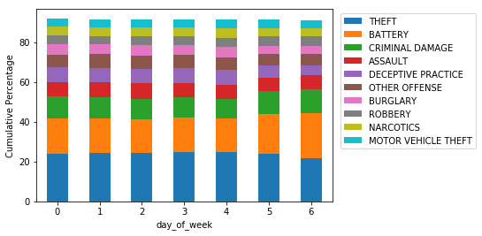

```python
row_idx = df['Primary Type'].value_counts().index[:10]
type_dow_plt_dat = round(type_dow_cross.div(type_dow_cross.sum(axis=0), axis=1).loc[row_idx,:]*100,2).T
plt_type_dow = type_dow_plt_dat.plot(kind='bar', stacked = True, rot = 0)
plt_type_dow.legend(bbox_to_anchor=(1.5,1), loc='upper right', ncol = 1)
_ = plt.ylabel("Cumulative Percentage")
```

### Ejercicio 5: (15 min)

Sospechamos que a lo largo de un día típico, la distribución de los lugares del crimen puede cambiar. Realice una prueba para determinar si este es el caso. Si esto es cierto, identifique el cambio potencial mediante la construcción de un gráfico de barras apiladas que muestre la proporción de delitos en cada una de las 10 ubicaciones principales para cada hora del día.

**Respuesta.** Discretizamos el tiempo en horas del día y realizamos la prueba de Chi-cuadrado:

```python
df["hour_of_day"] = df.date_py.dt.hour
hod_loc_cross = pd.crosstab(df['hour_of_day'], df['Location Description'])
g, p, dof, expctd = chi2_contingency(hod_loc_cross)
print("Prueba de independencia de los lugares del crimen y la hora del día: p-value =", p)
```

```
Prueba de independencia de los lugares del crimen y la hora del día: p-value = 0.0
```

Encontramos que la ubicación y la hora del día son realmente dependientes. Vamos a visualizar esto:

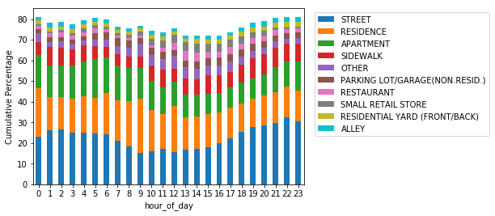

```python
col_idx = df['Location Description'].value_counts().index[:10]
hod_loc_plt_dat = round(hod_loc_cross.div(hod_loc_cross.sum(axis=1), axis=0).loc[:,col_idx]*100,2)
plt_hod_loc = hod_loc_plt_dat.plot(kind='bar', stacked = True, rot = 0)
plt_hod_loc.legend(bbox_to_anchor=(1.7,1), loc='upper right', ncol = 1)
_ = plt.ylabel("Cumulative Percentage")
```

Podemos ver que en la mañana (5 a.m. a 12 p.m.), los delitos en residencia (naranja) tienden a aumentar y después de las 6 p.m., los crímenes comienzan a darse en las calles.

## Conclusiones (5 min)

En este caso, realizamos la prueba de Chi-cuadrado para validar varios patrones y relaciones que observamos entre varias características en nuestros incidentes criminales EDA anteriores de Chicago. Esta prueba proporcionó evidencia estadística de que el patrón que vimos en las tablas de contingencia anteriormente no se debía solo al azar. Esto proporciona un fuerte respaldo para que el departamento de policía dé el gran paso de reorganizar su fuerza de acuerdo con nuestras observaciones.

## Ideas que nos debemos llevar (5 min)

En este caso, hemos aprendido otro método para validar estadísticamente los patrones que observamos en el análisis exploratorio de datos. Más específicamente, tenemos:

1. Aprendimos cómo las tablas de contingencia son útiles para detectar patrones en variables categóricas. En particular, hemos visto que tomar proporciones y usar gráficos de barras apiladas es útil para comprender mejor los resultados de una tabla de contingencia.
2. Aprendimos el concepto de independencia de características. Este es un concepto fundamental en estadísticas y análisis de datos. Si queremos detectar patrones en los datos, es fundamental que primero busquemos evidencia de dependencia entre las características.
3. Aprendimos a realizar pruebas de Chi-cuadrado para examinar si dos factores discretos son independientes. Esta prueba, junto con la prueba $t$, es uno de los pilares de la hipótesis estadística. Utilizará estas pruebas muy a menudo cuando analice datos.
4. Finalmente, hemos aprendido cómo lidiar con variables continuas como el tiempo al usar la prueba de Chi-cuadrado. Esto se hace creando categorías artificiales (pero significativas) que nos permiten implementar la prueba también en estos casos.